# What these things can do

Jonas Moss · Data Science and Analytics

22 October 2026

## Two kinds of contest

### Algorithm

- Several exact puzzles.
- Each has a right answer. Hidden tests check it.
- **Solved, or not.**

*Like: the shortest route through a network.*

### Heuristic

- One big problem. Nobody knows the best answer.
- Ten hours to do as well as you can.
- **The score is how good it is.**

*Like: routes for 1,000 delivery trucks, as cheap as possible.*

Heuristic is closer to real planning: no “solved”, only better.

## Competitive programming: the world finals

ICPC World Finals 2025: AI solves **12 of 12** problems, best human team **11**.

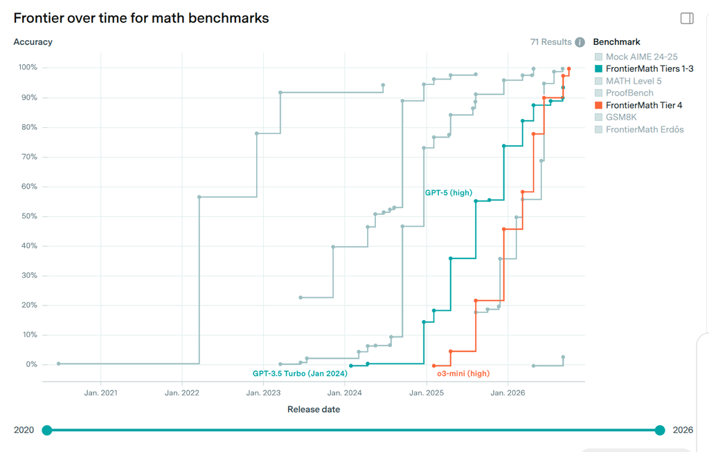

**FrontierMath:** unpublished problems written by mathematicians to stump AI. Tier 4 (orange) is research level.  
These tests are close to full, so the labs now also test on **open problems**.

Chart: [Epoch AI](https://epoch.ai/benchmarks), CC BY

## A released model on open problems

OpenAI, September: a curated set of **open** maths problems, ones nobody had solved.

[figure not shown]

**GPT-6 Astra**, released 3 September: up to about **1 in 6**

**Internal model**, unreleased: nearly **1 in 2**

The same Astra on FrontierMath Tier 4, the research-level test on the previous slide: **97.6%**

Claude users: on Epoch’s capability index, Claude Fable 5.1 scores within two points of GPT-6 Astra (164.5 against 166.3).

[OpenAI, 8 September 2026](https://openai.com/index/navier-stokes-solution/) · Capability index: [Epoch AI](https://epoch.ai/eci), 20 September 2026 · Tier 4: [Epoch AI](https://epoch.ai/benchmarks/frontiermath-tier-4-v2), Astra at medium reasoning, run data 20 September 2026

## Navier–Stokes

One of the seven **Millennium Prize Problems**. $1 million each.

**September 2026:** OpenAI reports a solution from an internal model: about **10,000 concurrent agents**, **88 hours**. The proof is checked by computer.

[OpenAI, 8 September 2026](https://openai.com/index/navier-stokes-solution/) · [Clay Mathematics Institute](https://www.claymath.org/millennium-problems/)

## 6 October: the same internal model

OpenAI posed about 4,000 **open** problems to it, as a test: problems nobody had solved.

**4,000** open problems tried

**372** results

**719** papers

**3 hours** of compute per result

**42%** checked by computer

By one count, **90 of the 500** best-known open problems in mathematics.

OpenAI: “Some of the unformalized results could have issues.” Three papers were withdrawn in the first two days.

[OpenAI, 6 October 2026](https://openai.com/index/sharing-ai-progress-in-mathematics/) · github.com/openai/math

## The biggest day in history?

> It isn’t an overstatement to say that this is probably the biggest day of scientific advancement in history.

**Joshua Gans**, economist, Rotman School of Management, Toronto

> Big, big, big, big props for quasiriemann and no Siegel zeroes […] It’s obviously the most significant moment in mathematical history.

**Levent Alpöge**, mathematician at Anthropic, on OpenAI’s results

The New York Times front page that day had no mathematics.

[Joshua Gans, 7 October 2026](https://joshuagans.substack.com/p/openai-drops-a-bomb-on-maths) · [Alpöge on X, 7 October 2026](https://x.com/__alpoge__/status/2107616859595981117)

## A Fields medallist’s reaction

> Not a single one of the major open problems I have publicly mentioned throughout my career […] was left untouched by the announcement. Everything has been claimed to be proved.

> I expected to see a few of them in the list. But not all of them. Not all at once.

**Hugo Duminil-Copin**, Fields Medal 2022

“The shock is immense. I am paralysed. Tomorrow, we will find a way forward.”

[Proofs and Prompts: 100+ reactions to 100+ solutions, 8 October 2026](https://proofsandprompts.com/2026/10/08/100-reactions-to-100-solutions/)

## For teaching: animations, written as code

[figure not shown]

Made by Claude Code for this slide: one SVG file, no video software. Also in the Claude app: [Design animations](https://aiblewmymind.substack.com/p/claude-design-animations), [Motion](https://support.claude.com/en/articles/17454997-get-started-with-claude-motion).